# Exercise 1 - Loading Data

### Data Source: URL Link to your datasource:

https://www.kaggle.com/pvaibhav1995/covid19-dataset#COVID19_open_line_list.csv

# Description

This is a Covid-19 dataset. There are two datasets.

The first dataset, covid_data.csv, contains data like country, age, sex, lives in Wuhan, symptoms, chronic diseases, and the outcome (death, recovered, etc) for the people affected.

The second dataset, covid_outcome.csv, contains information on Confirmed cases, deaths, and recoveries in various countries.

# Analysis strategy

With the first dataset, I aim to analyze the types of symptoms that the people infected by Covid-19 suffered. For this, I will have to segregate the text in symptoms into individual symptoms and map it to a new column in the dataset.

We will also look at the average age group for people who survived the Covid-19 infection and those who could not. We will see how many people visited Wuhan (directly or traveled via Wuhan), and were tested positive for Corona Virus. We will look at people battling some of the chronic diseases and the outcome in terms of recovered, death, sever, hospitalized, or discharged from the hospital.

Using the second database, we will look at the countries with maximum number of cases confirmed. We will also look at top 5 countries with maxixum number of deaths recorded.

To begin any analysis in the first dataset, we need to clean follwoing columns:

1. The ID column has empty values. Resetting the column, so that later data can be selected using Index. Then, set it as the index column.
2. Clean Column 'AGE': Replace Dates with Age Irrelevant Entry 'Belgium' in age column Replace null values with 0 Replace entries with range like 30 - 40 with average average of the two numbers
3. In symptoms columns, for values like (fever 37.1 C), the parenthesis has to removed as they are causing error in further processing.

   Correcting spelling Mistakes.

   And correcting entries to treat body pain and body ache, running nose and runny nose, respiratory complaints, respiratory distress, respiratory problems lungs, respiratory problems, and respiratory stress as respiratory symptoms. And so on.
4. Clean Column Outcome Replacing: Died and dead with death. Discharge with Discharged. Intensive care and critical conditiona with sever. Released from quarantine and Stable with recovered. recovering at home 03.03.2020 with hospitalized. Recovering at home 03.03.2020 with hospitalized.

   For record with a date_admission_hospital, filling the outcome column with 'hosptalized' status.
5. Clean column sex by replacing NA or empty values with 'other' and junk values like 4000 with 'other'

# Read in the file

Downloading two files:

1. covid_data.csv: one file contains age, symptoms, chronic diseases and other infromation. We will use this file to gather information on the age group affected, and the symptoms experienced by infected population.
2. covid_outcome.csv: contains data like Province/State Country/Region Last Update Confirmed Deaths Recovered This file is more suited to do analysis on overall cases, deaths, recoveries in different countries.

```python
import pandas as pd
import numpy as np
import seaborn as sns
import matplotlib.pyplot as plt

covid = pd.read_csv('covid_data.csv')
covid_outcome = pd.read_csv('covid_outcome.csv',index_col=0)
covid.info()
```

```
<class 'pandas.core.frame.DataFrame'>
RangeIndex: 127759 entries, 0 to 127758
Data columns (total 34 columns):
ID                          127522 non-null object
age                         5225 non-null object
sex                         5115 non-null object
city                        57881 non-null object
province                    117927 non-null object
country                     127709 non-null object
wuhan(0)_not_wuhan(1)       64422 non-null float64
latitude                    111519 non-null object
longitude                   111519 non-null object
geo_resolution              111519 non-null object
date_onset_symptoms         1046 non-null object
date_admission_hospital     982 non-null object
date_confirmation           126540 non-null object
symptoms                    1017 non-null object
lives_in_Wuhan              1897 non-null object
travel_history_dates        768 non-null object
travel_history_location     2690 non-null object
reported_market_exposure    1195 non-null object
additional_information      4286 non-null object
chronic_disease_binary      568 non-null object
chronic_disease             42 non-null object
source                      120840 non-null object
sequence_available          1106 non-null object
outcome                     333 non-null object
date_death_or_discharge     230 non-null object
notes_for_discussion        299 non-null object
location                    2534 non-null object
admin3                      10982 non-null object
admin2                      52487 non-null object
admin1                      68579 non-null object
country_new                 76323 non-null object
admin_id                    76073 non-null object
data_moderator_initials     12830 non-null object
travel_history_binary       217 non-null float64
dtypes: float64(2), object(32)
memory usage: 33.1+ MB
```

# Cleaning the Data

## Clean Column 'ID'

The ID column has empty values. Resetting the column, so that later data can be selected using Index. Then, set it as the index column.

```python
covid['ID'] = range(1, 1 + len(covid) )
covid.set_index('ID')
```

| ID | age | sex | city | province | country | wuhan(0)_not_wuhan(1) | latitude | longitude | geo_resolution | date_onset_symptoms | ... | date_death_or_discharge | notes_for_discussion | location | admin3 | admin2 | admin1 | country_new | admin_id | data_moderator_initials | travel_history_binary |
| --- | --- | --- | --- | --- | --- | --- | --- | --- | --- | --- | --- | --- | --- | --- | --- | --- | --- | --- | --- | --- | --- |
| 1 | NaN | NaN | NaN | Tucuman | Argentina | NaN | -26.94 | -65.34 | admin1 | NaN | ... | NaN | NaN | NaN | NaN | NaN | NaN | NaN | NaN | NaN | NaN |
| 2 | NaN | NaN | NaN | Buenos Aires | Argentina | NaN | -34.6033 | -58.3817 | admin1 | NaN | ... | NaN | NaN | NaN | NaN | NaN | NaN | NaN | NaN | NaN | NaN |
| 3 | NaN | NaN | NaN | Buenos Aires | Argentina | NaN | -34.6033 | -58.3817 | admin1 | NaN | ... | NaN | NaN | NaN | NaN | NaN | NaN | NaN | NaN | NaN | NaN |
| 4 | NaN | NaN | NaN | Buenos Aires | Argentina | NaN | -34.6033 | -58.3817 | admin1 | NaN | ... | NaN | NaN | NaN | NaN | NaN | NaN | NaN | NaN | NaN | NaN |
| 5 | NaN | NaN | NaN | Cordoba | Argentina | NaN | -31.4167 | -64.1833 | admin1 | NaN | ... | NaN | NaN | NaN | NaN | NaN | NaN | NaN | NaN | NaN | NaN |
| ... | ... | ... | ... | ... | ... | ... | ... | ... | ... | ... | ... | ... | ... | ... | ... | ... | ... | ... | ... | ... | ... |
| 127755 | NaN | NaN | Vancouver | British Columbia | Canada | NaN | 49.25 | -123.1 | point | NaN | ... | NaN | NaN | NaN | NaN | British Columbia | Canada | 2 | #REF! | NaN | NaN |
| 127756 | NaN | NaN | Vancouver | British Columbia | Canada | NaN | 49.25 | -123.1 | point | NaN | ... | NaN | NaN | NaN | NaN | British Columbia | Canada | 2 | #REF! | NaN | NaN |
| 127757 | NaN | NaN | Vancouver | British Columbia | Canada | NaN | 49.25 | -123.1 | point | NaN | ... | NaN | NaN | NaN | NaN | British Columbia | Canada | 2 | #REF! | NaN | NaN |
| 127758 | NaN | NaN | Vancouver | British Columbia | Canada | NaN | 49.25 | -123.1 | point | NaN | ... | NaN | NaN | NaN | NaN | British Columbia | Canada | 2 | #REF! | NaN | NaN |
| 127759 | NaN | NaN | Vancouver | British Columbia | Canada | NaN | 49.25 | -123.1 | point | NaN | ... | NaN | NaN | NaN | NaN | British Columbia | Canada | 2 | #REF! | NaN | NaN |

127759 rows × 33 columns

## Removing Columns that are not referenced for analysis

```python
covid.pop('latitude')
covid.pop('longitude')
covid.pop('geo_resolution')
covid.pop('admin1')
covid.pop('admin2')
covid.pop('admin3')
covid.pop('location')
covid.pop('admin_id')
covid.pop('country_new')
covid.pop('data_moderator_initials')
covid.pop('source')
covid.pop('sequence_available')
covid.pop('notes_for_discussion')
covid.pop('additional_information')
covid.info()
```

```
<class 'pandas.core.frame.DataFrame'>
RangeIndex: 127759 entries, 0 to 127758
Data columns (total 20 columns):
ID                          127759 non-null int32
age                         5225 non-null object
sex                         5115 non-null object
city                        57881 non-null object
province                    117927 non-null object
country                     127709 non-null object
wuhan(0)_not_wuhan(1)       64422 non-null float64
date_onset_symptoms         1046 non-null object
date_admission_hospital     982 non-null object
date_confirmation           126540 non-null object
symptoms                    1017 non-null object
lives_in_Wuhan              1897 non-null object
travel_history_dates        768 non-null object
travel_history_location     2690 non-null object
reported_market_exposure    1195 non-null object
chronic_disease_binary      568 non-null object
chronic_disease             42 non-null object
outcome                     333 non-null object
date_death_or_discharge     230 non-null object
travel_history_binary       217 non-null float64
dtypes: float64(2), int32(1), object(17)
memory usage: 19.0+ MB
```

## Clean Column 'AGE':

Clean Column 'AGE':

1. Replace Dates with Age
2. Irrelevant Entry 'Belgium' in age column
3. Make sure NAN is pd.np.nan
4. Replace entries with range like 30 - 40 with average average of the two numbers

```python
def age_range_avg(x):
    if type(x) == str:
#         Due lack of time using hard coded values for dates to age conversion
        if x.find('Aug') != -1:
            x = 51.7
        elif x.find('Oct') != -1:
            x = pd.np.nan
        elif x.find('May') | x.find('May') != -1:
            x = 60.1
        elif x.find('Jan') != -1:
            x = 0.33
        elif x.find('-') != -1:
#             For values like 30-40 calculate avg using 30 + 40 / 2
            ages = x.split("-")
            ages = pd.to_numeric(ages)
            avg = 0
            for age in ages:
                avg = avg + age
            avg = avg / len(ages)
            x = avg
    if pd.isnull(x):
        x = 0
    return x

print("before",covid['age'].unique())
covid['age'] = covid.age.apply( lambda x: age_range_avg(x) )
print("after",covid['age'].unique())
```

```
before [nan '23' '64' '71' '53' '40' '45' '30-39' '50-59' '60-69' '30' '65' '44'
 'Aug-68' '21-72' '26' '36' '43' '70' '52' '66' '27' '17' '51' '68' '35'
 '28' '58' '33' '31' '50' '24' '88' '29' '21' '78' '60' '63' '37' '32'
 '49' '20-29' '47' '18-99' '41' '39' '42' '38' '7' '40-49' '82' '61'
 '34-66' '62' '40-89' '80-89' '55' '0.25' '13-19' '69' '16' '8' '10' '25'
 '34' '55-74' '75-' '70-79' '79' '35-54' '55-' '95' '54' '40-50' '46' '48'
 '57' '56' '60-60' '80-80' '73' '0-18' '77' '67' '18-' '0-6' '0-10' '22'
 '74' '19-Oct' '83' '96' '76' '20' '19' '1.75' '9' '75' '18-65' '1'
 '54-56' '0.666666667' '74-76' '27-29' '80' '18' '72' '4' '59' '15'
 '61-80' '65-99' '81' '90-99' '50-69' '50-60' '92' '85' '91' '87' '14'
 '12' '19-65' '70-70' '60-70' '2' '30-70' '20-70' '20-69' '16-17' '94'
 'May-59' '60-' '27-40' '19-Jan' '18-50' '18-49' '41-60' '18-60' '60-99'
 '40-69' '30-69' '40-45' '5' '0-9' '3' '13-69' '30-40' '70-100' '0-60'
 '18 - 100' '0-20' '89' '30-35' '50-100' '60-100' '65-' '50-' '93' '84'
 '6' '20-30' '50-99' '18-20' '17-66' '13' '97' '11' '14-18' '30-60'
 '33-78' '16-80' '36-45' '23-72' '0.58333' '0.08333' '20-39' '22-80'
 '19-77' '70-82' '25-89' '15-88' '86' '21-39' '0-19' '80-' '21-']
after [0 '23' '64' '71' '53' '40' '45' 34.5 54.5 64.5 '30' '65' '44' 51.7 46.5
 '26' '36' '43' '70' '52' '66' '27' '17' '51' '68' '35' '28' '58' '33'
 '31' '50' '24' '88' '29' '21' '78' '60' '63' '37' '32' '49' 24.5 '47'
 58.5 '41' '39' '42' '38' '7' 44.5 '82' '61' 50.0 '62' 84.5 '55' '0.25'
 16.0 '69' '16' '8' '10' '25' '34' 74.5 '79' '95' '54' 45.0 '46' '48' '57'
 '56' 60.0 80.0 '73' 9.0 '77' '67' 3.0 5.0 '22' '74' '83' '96' '76' '20'
 '19' '1.75' '9' '75' 41.5 '1' 55.0 '0.666666667' 75.0 28.0 '80' '18' '72'
 '4' '59' '15' 70.5 82.0 '81' 94.5 59.5 '92' '85' '91' '87' '14' '12' 42.0
 70.0 65.0 '2' 16.5 '94' 60.1 33.5 0.33 34.0 50.5 39.0 79.5 49.5 42.5 '5'
 4.5 '3' 41.0 35.0 85.0 30.0 59.0 10.0 '89' 32.5 '93' '84' '6' 25.0 19.0
 '13' '97' '11' 55.5 48.0 40.5 47.5 '0.58333' '0.08333' 29.5 51.0 76.0
 57.0 51.5 '86' 9.5]
```

The AGE column has a lot of missing values. For analysis NA can be replaced with with mean of the ages available. This will help in analysing average ages impacted

```python
covid['age'] = pd.to_numeric(covid['age'])
covid1 = pd.DataFrame()
covid1['age1'] = covid.loc[ covid['age']!=0, 'age' ]
# replace NA in ages with mean of the ages
covid['age'] = covid['age'].replace(0, covid1['age1'].mean())
#delete column
covid1.pop('age1')
covid.loc[:,['age']]
```

|  | age |
| --- | --- |
| 0 | 49.333095 |
| 1 | 49.333095 |
| 2 | 49.333095 |
| 3 | 49.333095 |
| 4 | 49.333095 |
| ... | ... |
| 127754 | 49.333095 |
| 127755 | 49.333095 |
| 127756 | 49.333095 |
| 127757 | 49.333095 |
| 127758 | 49.333095 |

127759 rows × 1 columns

## Clean Column Symptoms

For values like (fever 37.1 C), the parenthesis has to removed as they are causing error in further processing. Correcting spelling Mistakes.

And correcting entries to treat body pain and body ache, running nose and runny nose, respiratory complaints, respiratory distress, respiratory problems lungs, respiratory problems, and respiratory stress as respiratory symptoms. And so on.

```python
word_dict = {
                ';': ',',
                '(': '',
                ')': '',
                '.': '',
                'and': ',',
                '?': '',
                '19':'',
                '20':'',
                '21':'',
                '22':'',
                '23':'',
                '371 ° c': '',
                'yes':'',
                'eventually':'',
                'showed':'',
                'general malaise': 'malasie',
                'severe dyspnea':'dyspnea',
                'rhinorrhea':'rhinorrhoea',
                'diarrheoa':'diarrhea',
                'diarrhoea':'diarrhea',
                'aches':'ache',
                'muscle ache': 'myalgia',
                'milagia': 'myalgia',
                'throath': 'throat',
                'muscle pain':'myalgia',
                'aching muscles':'myalgia',
                'muscular':'muscle',
                'muscle soreness':'myalgia',
                'mialgia':'myalgia',
                'sore muscle':'myalgia',
                'myalgias':'myalgia',
                'weak':'weakness',
                'lack of energy':'weakness',
                'systemic weakness':'weakness',
                'weaknessness':'weakness',
                'severe pneumonia':'pneumonia',
                'transient fatigue':'fatigue',
                'sore throa':'sore throat',
                'throatt':'throat',
                'sneezing':'sneeze',
                'malaise':'malasie',
                'chills':'cold',
                'cold cold':'cold',
                'conjuntivitis':'conjunctivitis',
                'contact of hcov-/brazil/spbr-01/':'',
                'cough symptoms':'cough',
                'couh':'cough',
                'coughing':'cough',
                'chest discomfort':'chest distress',
                'dry cough': 'cough',
                'between others':'',
                'body pain':'body ache',
                'fatigure':'fatigue',
                'general':'',
                'asymptomatic?':'asymptomatic',
                'arvi':'',
                'mausea':'nausea',
                'mile':'',
                'mild':'',
                'minor': '',
                'no respiratory symptoms':'',
                'no serious symptoms':'',
                'no symptoms':'',
                'joint pain' : 'joint myalgia',
                'running nose': 'runny nose',
                'respiratory complaints':'respiratory symptoms',
                'respiratory distress':'respiratory symptoms',
                'respiratory problems lungs':'respiratory symptoms',
                'respiratory problems':'respiratory symptoms',
                'respiratory stress':'respiratory symptoms',
                'rever':'fever',
                'severe':'',
                'sensation of chill':'cold',
                'similar to a respiratory infection': 'respiratory symptoms',
                'then':'',
                'unwellness':'feeling ill',
                '38':'',
                '℃':'',
                'chest pain': 'chest distress'
                }

def replace_str_in_a_column(x):
    if type(x) == str:
        for word in word_dict.keys():
            if x.find(word) != -1:
                x= x.replace(word,word_dict[word])
    return x

covid['symptoms'] = covid['symptoms'].str.lower()
covid['symptoms'] = covid.symptoms.apply( lambda x: replace_str_in_a_column(x) )
covid['symptoms'].unique()
```

```
array([nan, 'fever, cough , malasie', 'fever, cough, sore throat',
       'cough, fever, weakness',
       'cough, diarrhea, fever, rhinorrhoea, sneeze', 'pneumonitis',
       'anhelation, cough, fever, pleural effusion, weakness',
       'diarrhea, fever, nasal congestion, pleuritic chest distress, sore throat',
       'fever', 'dizziness, sore limbs', 'pneumonia', 'fever, pneumonia',
       'eye irritation, fever', 'cough, fever', 'fever, runny nose',
       'cough, fever, sore throat', 'dyspnea, fever',
       'cough, difficulty breathing, fever',
       'fever, headache, runny nose', 'cough, runny nose', 'fatigue',
       'fever  ° c', ',  cough', 'cough',
       'abdominal pain, pulmonary inflammation', 'sore throat',
       'feeling ill, cough', 'anorexia, fatigue',
       'abdominal pain, diarrhea, fever, malasie',
       'cough, fever, malasie', 'poor physical condition',
       'cough, fatigue, fever', 'cough, shortness of breath', '',
       'fever 3', 'fever 395 ', 'fever 377', 'fever 375', 'anorexia',
       'nausea, cough, pneumonia, fever', 'fever 2 , cough', 'fever 37 c',
       'malasie, headache', 'fever 37 , breathing difficulty',
       'fever 375 ,   , cough, malasie', 'sore throat, cough, fever 37 ',
       'difficulty breathing', 'fever, shortness of breath, pneumonia',
       'dyspnea', 'fever, cough', 'nausea', 'fever, fatigue',
       'chest tightness, fatigue',
       'fever, nasal congestion, runny nose, sore throat, cough',
       'fever 393', 'fever ', ', esophageal reflux',
       'cough, sputum, fever', 'cough, sore body, cold',
       'cold, cough, fatigue, fever',
       'cold, conjunctivitis, cough, fever', 'flu-like symptoms',
       'acute pharyngitis', 'fever, sore throat,  cough',
       'low fever 370 ', 'low fever 374 ', 'low fever 372 ° c, cough',
       'fever 395 , malasie', 'sore throat, fever, nasal discharge',
       'fever 374 ° c, pneumonia', 'fever 378 , cough',
       'fever -39 ° c, malasie', 'fever 1  cough, malasie, anorexia',
       'discharge, cough, sore throat, chest distress',
       'fever, cough, phlegm, dyspnea', 'fever, cough, phlegm',
       'fever 378  , sore throat', 'fever 371  , cough',
       'fever 3  , cough',
       'malasie, fever 37 , headache, toothache, pneumonia',
       'sore throat, cold', 'fever, cough, headache', 'fever 372',
       'cough, malasie', 'sore throat, fever -39 ', 'fatigue, fever  ',
```

[output cut: 104 more lines]

```
       'cough, diarrhea, vomiting', 'cold, cough, fever',
       'cough, fatigue, fever, weakness', 'cough, fever, gasp',
       'diarrhea, fever', 'chest distress, fever',
       'chest distress, cough, fever, gasp', 'cough, fever, cold',
       'dizziness, fever',
       'chest distress, chest distress, fever, weakness, dyspnea',
       'cough, fever, dyspnea', 'chest distress, cough, fever',
       'primary myelofibrosis', 'dyspnea, respiratory symptoms',
       'cough, fatigue, fever, headache',
       'cough, fatigue, fever, little sputum, myalgia',
       'obnubilation, somnolence', 'cough, expectoration, emesis, fever',
       'cold, myalgia', 'chest distress, cough, fatigue, fever',
       'fatigue, shortness of breath', 'cough, fever, grasp, dyspnea',
       'cough, fever, grasp', ', kidney failure , hypertension'],
      dtype=object)
```

## Clean Column Outcome

1. Replacing: Died and dead with death. Discharge with Discharged. Intensive care and critical conditiona with sever. Released from quarantine and Stable with recovered. recovering at home 03.03.2020 with hospitalized. Recovering at home 03.03.2020 with hospitalized.
2. For record with a date_admission_hospital, filling the outcome column with 'hosptalized' status.

```python
print('outcome values before cleaning',covid['outcome'].unique())

covid.loc[covid['outcome'].str.contains('not hospitalized',case=False,na=False),'outcome'] = pd.np.nan
covid.loc[covid['outcome'].str.contains('died|dead',case=False,na=False),'outcome'] = 'death'
covid.loc[covid['outcome'].str.contains('stable|quarantine',case=False,na=False),'outcome'] = 'recovered'
covid.loc[covid['outcome'].str.contains('discharge',case=False,na=False),'outcome'] = 'discharged'
covid.loc[covid['outcome'].str.contains('hospitalized|recovering at home',case=False,na=False),'outcome'] = 'hospitalized'
covid.loc[covid['outcome'].str.contains('critical condition|intensive care',case=False,na=False),'outcome'] = 'severe'

covid.loc[~covid['date_admission_hospital'].isna(), 'outcome_binary'] = '1'
covid.loc[~covid['date_admission_hospital'].isna() & covid['outcome'].isna(), 'outcome'] = 'hospitalized'

print('outcome values before cleaning',covid['outcome'].unique())
```

```
outcome values before cleaning [nan 'recovered' 'stable' 'discharged' 'discharge' 'death'
 'treated in an intensive care unit (14.02.2020)' 'severe'
 'released from quarantine' 'dead' 'Discharged' 'Discharged from hospital'
 'recovering at home 03.03.2020' 'not hospitalized' 'died'
 'Symptoms only improved with cough. Currently hospitalized for follow-up.'
 'critical condition, intubated as of 14.02.2020']
outcome values before cleaning [nan 'recovered' 'hospitalized' 'discharged' 'death' 'severe']
```

## Clean Column Sex

Replacing NA or empty values with 'other'. Replacing values like 4000 with 'other'.

```python
print('Values before cleaning',covid['sex'].unique())
covid.loc[covid['sex'].str.contains('female',case=False,na=False),'gender'] = 'female'
covid.loc[covid['sex'].isna(),'sex'] = 'other'
covid.loc[covid['sex']=='4000','sex'] = 'other'

print('Values after cleaning',covid['sex'].unique())
```

```
Values before cleaning [nan 'male' 'female']
Values after cleaning ['other' 'male' 'female']
```

## Clean Column Chronic_disease_binary

Replace text with 1

```python
covid.loc[covid['chronic_disease_binary'].str.contains('[a-z]', case=False, na=False, regex=True), 'chronic_disease_binary'] = 1
covid.loc[covid['chronic_disease_binary'].isna(), 'chronic_disease_binary'] = 0
covid['chronic_disease_binary'] = pd.to_numeric(covid['chronic_disease_binary'])
covid['chronic_disease_binary'].unique()
```

```
array([0., 1.])
```

## Clean Column wuhan(0)_not_wuhan(1)

If column 'lives_in_Wuhan' is yes then column 'wuhan(0)_not_wuhan(1)' msut contain a 1.

```python
covid.loc[covid['lives_in_Wuhan'].str.contains('yes|work in wuhan', case=False, na=False, regex=True), 'wuhan(0)_not_wuhan(1)'] = 1
covid['wuhan(0)_not_wuhan(1)'].sum()
```

```
50799.0
```

# Exercise 4 - Adding new Columns in the Data Frame

## For every unique symptom, insert a new column with the symptom name.

It contains a '1' if the the symptom name was found in 'symptoms' column.

1. Collecting individual values from text. E.g. Seggregating cell values like 'fever, cough, respiratory symptoms' in to array of [fever, cough, respiratory symptoms] Point 1 is done via custom function name 'get_individual_symptoms'
2. For fever, symptoms column contains values like fever, low/mild fever, fever (XX degree celsius). For analysis we are just looking at fever as a symptom, irrespective of degree and mildness. Points 2 & 3, done in custom function named 'generalize_symptoms'.
3. Similary for difficulty in breathing, symptoms column contains values with different wordings. For analysis we are just looking at 'difficulty breathing' as a symptom, if it contains words 'breath'. Points 2 & 3, done in custom function named 'generalize_symptoms'.
4. For every symptom create a new column in the covid dataframe and insert 1 if the person showed that symptom.  
   Point 4 is done in custom function name 'add_col_for_every_symptom'.
5. Inserting a new column 'symptoms_binary'. It contains a '1' if 'symptoms' column was not null for that record. This will ease in analysis later. Point 5 is done in custom function name 'add_col_for_every_symptom'.

```python
#     1. Collecting individual values from text into array 'arr1'
def get_individual_symptoms(symp):
    arr1 = []

    for x in symp:
        if type(x) == str:
            if x.find(',') != -1:
                a = x.split(',')
                arr1 = arr1 + a
            else:
                arr1.append(x)
    return arr1

# 2. For fever, symptoms column contains values like fever, low/mild fever, fever (XX degree celsius).
# 3. Similary for difficulty in breathing, symptoms column contains values with different wordings.
def generalize_symptoms(arr1):
    arr2 = []
    for x in arr1:
        x = str.strip(x)
        x = str(str.lower(x))
        if x.find('breath') != -1:
            x = 'difficulty breathing'
        elif x.find('fever') != -1:
            x = 'fever'
            arr2.append(x)
        elif x == 'symptoms' or x =='muscle' or x=='':
            x = x
        else:
            arr2.append(x)
    return arr2

# 4. For every symptom create a new column in the covid dataframe and insert 1 if the person showed that symptom.
def add_col_for_every_symptom(arr2):
    for x in arr2:
        covid[x] = 0
        if x == 'difficulty breathing':
            search_word = 'breath'
        else:
            search_word = x
            covid.loc[covid['symptoms'].str.contains(search_word, case=False, na=False), [x, 'symptoms_binary'] ] = 1
#             print("Unique Values for ",x," is ",covid[x].unique())

arr1 = []
unique_symptoms = covid['symptoms'].unique()
arr1 = get_individual_symptoms(unique_symptoms)
arr1 = np.unique(arr1)
arr2 = generalize_symptoms(arr1)
arr2 = np.unique(arr2)
np.sort(arr2)
print("Column numbers",covid.shape)
covid['symptoms_binary'] = 0
add_col_for_every_symptom(arr2)
print("New Columns for Unique Symptoms Added:",covid.columns[21:])
print("Column numbers after",covid.shape)
```

[output not shown]

```python
covid['symptoms_binary'].unique()
```

```
array([0, 1], dtype=int64)
```

## Inserting a new column 'outcome_binary'.

It contains a '1' if 'outcome' column was not null for that record. This will ease in analysis later.

```python
# covid1.pop('outcome_binary')
covid['outcome_binary'] = 0
covid.loc[ ( covid['outcome'].str.contains('[A-Z]', case=False, na=False, regex=True) ) , 'outcome_binary'] = 1
covid['outcome_binary'].unique()
```

```
array([0, 1], dtype=int64)
```

# Pandas insights

## Analysis on people infected by corona

1150 people were infected by this virus out of 127750 cases given in the dataset

```python
covid_infected = covid.loc[covid['outcome_binary'] == 1]
covid_infected.shape[0]
```

```
1150
```

### Average age of people who recovered (survived :) )

```python
covid_recovered = covid_infected.loc[covid['outcome'] == 'recovered']
covid_recovered['age'].describe()
```

```
count    88.000000
mean     47.015141
std      12.800976
min       2.000000
25%      46.500000
50%      49.333095
75%      51.000000
max      87.000000
Name: age, dtype: float64
```

### Average age of people who died

Whereas as per analysis of people who died, 50% of population were between the age of 65 and 84, which is higher than the age group of 75% of surviors.

```python
covid_died = covid_infected.loc[covid['outcome'] == 'death']
covid_died['age'].describe()
```

```
count    98.000000
mean     71.889436
std      14.050484
min      36.000000
25%      65.000000
50%      74.500000
75%      84.500000
max      95.000000
Name: age, dtype: float64
```

# Groupby analysis

### Top five countries with people infected by Corona

China, Italy, South Korea, Iran, and Spain.

```python
covid_outcome[['Confirmed']].apply(np.mean)
covid_outcome_sum = covid_outcome.groupby('Country/Region').agg({'Confirmed':['sum'],'Deaths':['sum'],'Recovered':['sum']})
covid_outcome_sum.sort_values(by=('Deaths', 'sum'),ascending=False,inplace=True)
covid_outcome_sum.head(5)
```

| Country/Region | Confirmed sum | Deaths sum | Recovered sum |
| --- | --- | --- | --- |
| Mainland China | 2797319.0 | 90161.0 | 1154040.0 |
| Italy | 118103.0 | 6773.0 | 9904.0 |
| Iran | 88374.0 | 3466.0 | 24019.0 |
| South Korea | 104758.0 | 733.0 | 2849.0 |
| Spain | 21519.0 | 538.0 | 1242.0 |

China, Italy, and Iran.

```python
covid_outcome_sum.sort_values(by=('Deaths', 'sum'),ascending=False,inplace=True)
covid_outcome_sum.head(3)
```

| Country/Region | Confirmed sum | Deaths sum | Recovered sum |
| --- | --- | --- | --- |
| Mainland China | 2797319.0 | 90161.0 | 1154040.0 |
| Italy | 118103.0 | 6773.0 | 9904.0 |
| Iran | 88374.0 | 3466.0 | 24019.0 |

### Cases of being infected by corona for people battling a chronic disease

Out of 561 people with history of/ battling chronic disease:

- total of 89 people were infected
- total of 24 people died
- total of 1 perosn recovered
- 59 hospitalized

```python
print("Total number of people battling chronic diseases: ",covid['chronic_disease_binary'].sum())
covid_infected_chronic = covid_infected.groupby('outcome').agg({'chronic_disease_binary':'sum'})
covid_infected_chronic
```

```
Total number of people battling chronic diseases:  561.0
```

| outcome | chronic_disease_binary |
| --- | --- |
| death | 24.0 |
| discharged | 5.0 |
| hospitalized | 59.0 |
| recovered | 1.0 |
| severe | 0.0 |

```python
covid_infected_chronic = covid.groupby('outcome_binary').agg({'symptoms_binary':'sum','cough':'sum','sore throat':'sum'})
covid_infected_chronic
```

| outcome_binary | symptoms_binary | cough | sore throat |
| --- | --- | --- | --- |
| 0 | 313 | 153 | 26 |
| 1 | 400 | 168 | 34 |

### Out of those infected by corona, what are the top 5 symptoms they experienced?

It can be easily seen that amongst those infected, the prominent symptoms were of FEVER, and COUGH. And symptoms of fatigue, sore throat, myalgia, cold, runny nose, pneumonitis, weakness, and pneumonia were observed.

```python
covid_infected_symp = covid_infected[covid_infected.columns[23:]].sum()

for index, value in covid_infected_symp.items():
    if value == 0:
        covid_infected_symp.drop(index,axis=0,inplace=True)

covid_infected_symp.sort_values(ascending=False,inplace=True)
print(covid_infected_symp.head(5))
covid_infected_symp = covid_infected_symp.to_frame()
```

```
fever          289
cough          168
sore throat     34
fatigue         31
myalgia         26
dtype: int64
```

# Univariate plots (5 points)

Provide at least 3 univariate plots

## Univariate plot 1

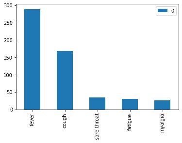

```python
# covid_outcome1_country.sort_values(by=('outcome', 'count'),ascending=False,inplace=True)
covid_infected_symp = covid_infected_symp.transpose()
covid_infected_symp
covid_infected_symp[0:5].plot(kind='bar')
```

## Univariate plot 2

Plotting age of people who recovered (survived :) )

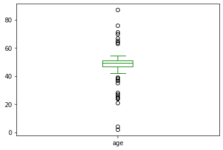

```python
covid_recovered['age'].plot(kind='box',color='green')
```

Plotting age of people who died

## Univariate plot 3

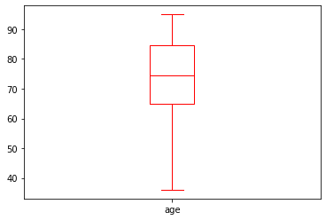

```python
covid_died['age'].plot(kind='box',color='red')
```

## Count of People with chronic disease.

0 -> people with no chronic disease 1 -> poeple with chronic disease

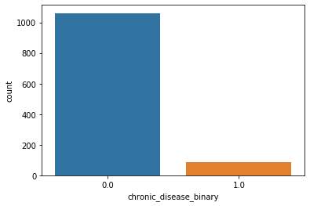

```python
sns.countplot(x='chronic_disease_binary', data=covid_infected)
```

# Bivariate plots (10 points)

Provide at least 2 bivariate plots

## Bivariate plot 1

Count plot to show counts for categorical values of Symptoms_binary namely: 0 (had no prior sypmtom) and 1 (had a prior sypmtom).

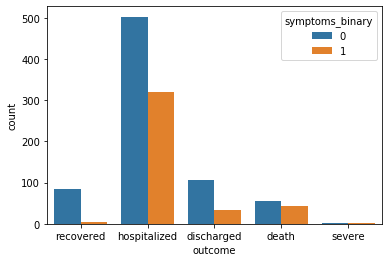

```python
sns.countplot(x='outcome', hue='symptoms_binary', data=covid_infected)
```

## Bivariate plot 2

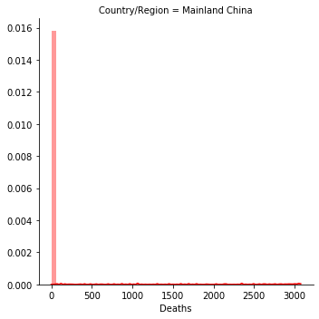

```python
covid_outcome_sum5 =  covid_outcome.loc[ covid_outcome['Country/Region']=='Mainland China']
g = sns.FacetGrid(covid_outcome_sum5, col='Country/Region',height=5)
g.map(sns.distplot,'Deaths',color='red')
```

## For those infected by Covid-19, how many had an direct exposure to Wuhan city?

outcome_binary = 1 for people infected by the  
wuhan(0)_not_wuhan(1) = 1 if the person visited Wuhan

```
                wuhan(0)_not_wuhan(1)
outcome_binary
1                              1065.0
```

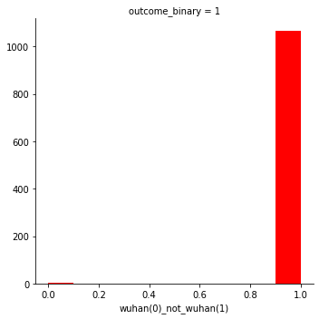

```python
print(covid_infected.groupby('outcome_binary').agg({ 'wuhan(0)_not_wuhan(1)':'sum'}))
g = sns.FacetGrid(covid_infected, col='outcome_binary',height=5)
g.map(plt.hist,'wuhan(0)_not_wuhan(1)',color='red')
```

# Multivariate plot (10 points)

Provide at least 1 multivariate Multivariate plot 1

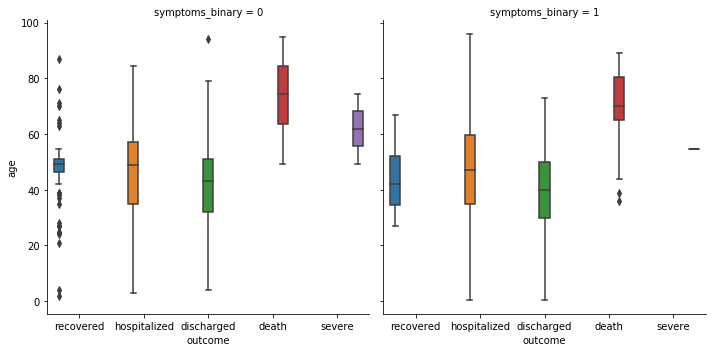

```python
sns.catplot( x='outcome', y='age', hue='outcome', col='symptoms_binary', kind='box', data=covid_infected )
```

# Conclusions (20 points)

# Code is functional and runs without error (10 pts)

Verify this by following these steps. 1) Reset Kernel. Kernel>>Restart Kernel... Working 2) Rerun all cells. Run>>Run All Cells Working. I wounld request you to rerun ## Univariate plot 1 though. For some reason it won't show me the correct output while rerun all.